# Results Section (study1adults)

Adam Stone, PhD

10-09-2017

# Refreshing Ourselves

> The main goal of the study is to see if comprehension is related to gaze behavior and if AoA impacts gaze behavior.

**Key Questions:** Can gaze behavior reflect whether or not a person can understand the story? When a person has a harder time understanding a difficult story, maybe because they lack the skills, can this be observed in gaze behavior?

> It is more important to show that our behavioral measure IS sensitive to effects of AoA. Period. *The cause is secondary.*

Now let’s load in the dataset called `cleanpercentdata.csv`. It contains item-level data showing the percent of looking for each AOI (10 AOIs total) for each story and each participant *still in the study*. All data defined as “bad” (entire participants with poor calibration, or individual stories with too little looking data) have been dropped. We will then move this to subject-level by averaging each participant’s two forward stories together and two reversed stories together.

```r
#library(corrplot)
#library(Hmisc)
library(tidyverse)
library(stringr)
library(lme4)
library(lmerTest)
library(prettydoc)
library(broom)
library(knitr)
library(xtable)
library(kableExtra)
library(viridis)
options(knitr.table.format = "html")
# Import!
data <- read_csv('cleanpercentdata.csv',col_types =
                   cols(
                     id = col_integer(),
                     participant = col_character(),
                     hearing = col_character(),
                     videogroup = col_character(),
                     aoagroup = col_character(),
                     languagegroup = col_character(),
                     maingroup = col_character(),
                     video = col_character(),
                     story = col_character(),
                     direction = col_character(),
                     age = col_double(),
                     selfrate = col_double(),
                     signyrs = col_double(),
                     aoasl = col_integer(),
                     acc = col_double(),
                     aoi = col_character(),
                     percent = col_double()
                   ))
# And factorize
data <- data %>%
  mutate(participant = as.factor(participant)) %>%
  mutate(id = as.factor(id)) %>%
  mutate(hearing = as.factor(hearing)) %>%
  mutate(videogroup = as.factor(videogroup)) %>%
  mutate(aoagroup = as.factor(aoagroup)) %>%
  mutate(languagegroup = as.factor(languagegroup)) %>%
  mutate(maingroup = as.factor(maingroup)) %>%
  mutate(video = as.factor(video)) %>%
  mutate(story = as.factor(story)) %>%
  mutate(direction = as.factor(direction)) %>%
  mutate(aoi = as.factor(aoi))
dataoriginal <- data # Save item-level data just in case
# Take out HearingNoviceASL
# data <- data %>%
#   filter(maingroup!="HearingNoviceASL")
# Load awesome function to make correlation tables with stars for significance
# From: https://myowelt.blogspot.co.uk/2008/04/beautiful-correlation-tables-in-r.html
corstarsl <- function(x){
require(Hmisc)
x <- as.matrix(x)
R <- Hmisc::rcorr(x)$r
p <- Hmisc::rcorr(x)$P
## define notions for significance levels; spacing is important.
mystars <- ifelse(p < .001, "***", ifelse(p < .01, "** ", ifelse(p < .05, "* ", " ")))
## trunctuate the matrix that holds the correlations to two decimal
R <- format(round(cbind(rep(-1.11, ncol(x)), R), 2))[,-1]
## build a new matrix that includes the correlations with their apropriate stars
Rnew <- matrix(paste(R, mystars, sep=""), ncol=ncol(x))
diag(Rnew) <- paste(diag(R), " ", sep="")
rownames(Rnew) <- colnames(x)
colnames(Rnew) <- paste(colnames(x), "", sep="")
## remove upper triangle
Rnew <- as.matrix(Rnew)
Rnew[upper.tri(Rnew, diag = TRUE)] <- ""
Rnew <- as.data.frame(Rnew)
## remove last column and return the matrix (which is now a data frame)
Rnew <- cbind(Rnew[1:length(Rnew)-1])
return(Rnew)
}
# Pull out subject info, and averge the accuracy scores
data.subjectinfo <- data %>%
  select(-aoi,-percent,-video,-story) %>%
  distinct() %>%
  group_by(participant,direction) %>%
  mutate(acc = mean(acc,na.rm=TRUE)) %>%
  distinct()
# Now collapse eye gaze data to subject-level
data <- data %>%
  group_by(participant,direction,aoi) %>%
  dplyr::summarize(percent = mean(percent,na.rm=TRUE))
data[data=="NaN"] <- NA
# Join subject info with data that's now subject-level
data <- left_join(data,data.subjectinfo, by=c("participant","direction"))
# Set reference levels
data$maingroup <- relevel(data$maingroup, ref="DeafNative")
# data.face3 <- filter(data2, aoi == "eyes" | aoi == "mouth" | aoi == "chin") %>%
#   mutate(aoi = as.factor(aoi))
# data.face3$aoi <- factor(data.face3$aoi, levels=c("eyes","mouth","chin"))
# data.face3$aoi <- relevel(data.face3$aoi, ref="eyes")
# But now we need to go back and add in a complete lexical recall dataset, even including those trials that got thrown out in 03eyegaze.nb.html. Because the lexical accuracy data is still good. So let's work on that.
cleanlexdata <- read_csv('cleandata.csv',col_types =
                   cols(
                     id = col_integer(),
                     participant = col_character(),
                     hearing = col_character(),
                     videogroup = col_character(),
                     aoagroup = col_character(),
                     languagegroup = col_character(),
                     maingroup = col_character(),
                     video = col_character(),
                     story = col_character(),
                     direction = col_character(),
                     age = col_double(),
                     selfrate = col_double(),
                     signyrs = col_double(),
                     aoasl = col_integer(),
                     acc = col_double(),
                     aoi = col_character(),
                     percent = col_double()
                   ))
cleanlexdata <- cleanlexdata %>%
  select(participant,direction,acc) %>%
  group_by(participant,direction) %>%
  dplyr::summarize(acc = mean(acc,na.rm=TRUE)) %>%
  ungroup()
data <- data %>%
  select(-acc) %>%
  left_join(cleanlexdata,by=c("participant","direction")) %>%
  ungroup() %>%
  mutate(direction = as.factor(direction),
         participant = as.factor(participant))
```

# Participant Characteristics

Let’s do the basic participant table here.

```r
groupmeans <- data %>%
  ungroup() %>%
  select(id,participant,maingroup,age,selfrate,signyrs,aoasl) %>%
  distinct() %>%
  group_by(maingroup) %>%
  dplyr::summarize(n = n(),
            age.m = mean(age),
            age.sd = sd(age),
            selfrate.m = mean(selfrate),
            selfrate.sd = sd(selfrate),
            signyrs.m = mean(signyrs),
            signyrs.sd = sd(signyrs),
            aoasl.m = mean(aoasl),
            aoasl.sd = sd(aoasl))
kable(groupmeans, digits=1) %>% kable_styling(bootstrap_options = c("striped", "hover", "condensed"))
```

| maingroup | n | age.m | age.sd | selfrate.m | selfrate.sd | signyrs.m | signyrs.sd | aoasl.m | aoasl.sd |
| --- | --- | --- | --- | --- | --- | --- | --- | --- | --- |
| DeafNative | 12 | 33.0 | 9.2 | 5.0 | 0.0 | 32.6 | 9.4 | 0.2 | 0.5 |
| DeafEarlyASL | 9 | 34.8 | 6.6 | 5.0 | 0.0 | 29.8 | 7.6 | 5.0 | 2.7 |
| DeafLateASL | 8 | 38.0 | 5.9 | 5.0 | 0.0 | 23.2 | 5.3 | 14.2 | 3.0 |
| HearingLateASL | 12 | 28.9 | 6.2 | 4.6 | 0.5 | 11.8 | 4.8 | 17.2 | 3.4 |
| HearingNoviceASL | 11 | 20.2 | 1.3 | 3.0 | 0.7 | 2.4 | 1.0 | 17.6 | 1.8 |

```r
#groupmeans
```

# Lexical Recall Data, Summarized.

Quick summary of lexical recall data here. We have to collapse here as well from subject-level to group-level.

```r
data.groupacc <- data %>%
  ungroup() %>%
  select(-aoi,-percent) %>%
  distinct() %>%
  group_by(maingroup,direction) %>%
  dplyr::summarize(mean = mean(acc, na.rm=TRUE),
            sd = sd(acc, na.rm=TRUE))
data.acc1 <- data.groupacc %>%
  select(-mean) %>%
  spread(direction,sd) %>%
  rename(forward.sd = forward,
         reversed.sd = reversed)
data.acc2 <- data.groupacc %>%
  select(-sd) %>%
  spread(direction,mean) %>%
  rename(forward.mean = forward,
         reversed.mean = reversed)
groupcount <- select(groupmeans,maingroup,n)
data.groupacc <- left_join(data.acc2,data.acc1, by="maingroup") %>%
  left_join(groupcount, by="maingroup") %>%
  # mutate(forward.se = forward.sd/sqrt(n),
  #        reversed.se = reversed.sd/sqrt(n)) %>%
  #select(maingroup,n,forward.mean,forward.sd,forward.se,reversed.mean,reversed.sd,reversed.se)
  select(maingroup,n,forward.mean,forward.sd,reversed.mean,reversed.sd)
#data.acc
kable(data.groupacc, digits=2) %>% kable_styling(bootstrap_options = c("striped", "hover", "condensed"))
```

| maingroup | n | forward.mean | forward.sd | reversed.mean | reversed.sd |
| --- | --- | --- | --- | --- | --- |
| DeafNative | 12 | 0.85 | 0.05 | 0.77 | 0.10 |
| DeafEarlyASL | 9 | 0.84 | 0.04 | 0.66 | 0.09 |
| DeafLateASL | 8 | 0.87 | 0.06 | 0.72 | 0.04 |
| HearingLateASL | 12 | 0.87 | 0.07 | 0.69 | 0.09 |
| HearingNoviceASL | 11 | 0.78 | 0.11 | 0.64 | 0.11 |

And a boxplot that can go with it.

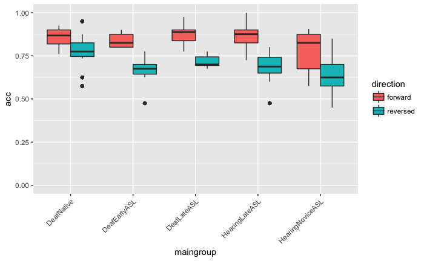

```r
ggplot(data,aes(maingroup,acc,fill=direction)) +
  geom_boxplot() +
  scale_y_continuous(limits=c(0,1)) +
  theme(axis.text.x=element_text(angle=45,hjust=1))
```

And Rain wanted the error plot so here it is. Lines represent SEM. Good to have this too!

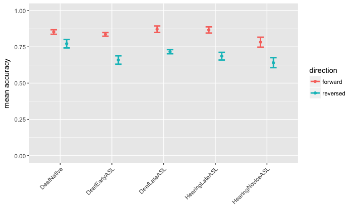

```r
data.acc1 <- data.acc1 %>%
  ungroup() %>%
  gather(direction,sd,forward.sd:reversed.sd) %>%
  mutate(direction = str_sub(direction,1,-4))
data.acc2 <- data.acc2 %>%
  ungroup() %>%
  gather(direction,mean,forward.mean:reversed.mean) %>%
  mutate(direction = str_sub(direction,1,-6))
data.acc.se <- left_join(data.acc1,data.acc2, by=c("maingroup","direction")) %>%
  left_join(groupcount, by="maingroup") %>%
  mutate(se = sd/sqrt(n))
ggplot(data.acc.se,aes(maingroup,mean,color=direction)) +
  geom_point(position=position_dodge(0.5)) +
  geom_errorbar(aes(ymin=mean-se,ymax=mean+se),width=0.25,size=1,position=position_dodge(0.5)) +
  scale_y_continuous(limits=c(0,1)) +
  theme(axis.text.x=element_text(angle=45,hjust=1)) + xlab("") + ylab("mean accuracy")
```

# Eye Gaze Data, Summarized.

I guess we should have a big table of means and SDs for all AOIs for each group for forward and backward. I’ll write the code for this later. For now, here’s the boxplot. This is the part where we will say, from all the data we have concluded that we can work with **three base AOIs** from here on due to sufficient data: chin, eyes, and mouth.

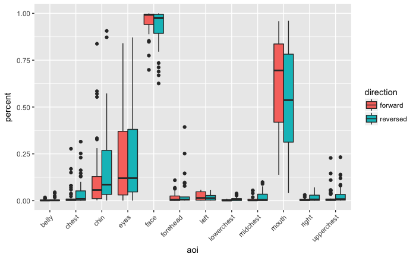

```r
data.aoionly <- data %>%
  filter(aoi != "facechest" & aoi != "mouthchin" & aoi != "moutheyes")
ggplot(data.aoionly,aes(aoi,percent,fill=direction)) +
  geom_boxplot() +
  scale_y_continuous(limits=c(0,1)) +
  theme(axis.text.x=element_text(angle=45,hjust=1))
```

THEN we can show heat maps too. For this I would include forehead and upperchest just to give it some dimension.

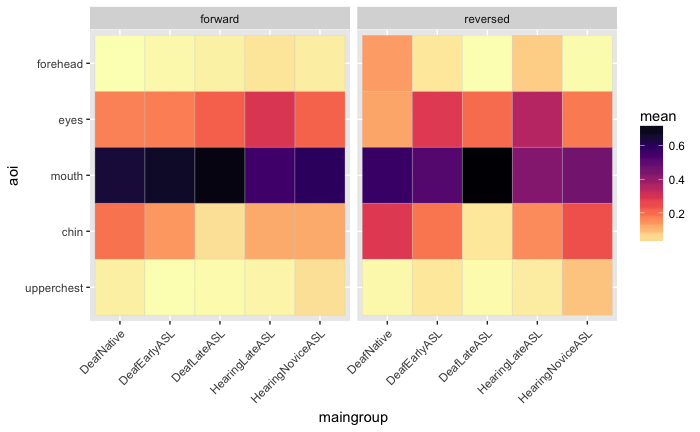

```r
data.five <- data %>%
  ungroup() %>%
  filter(aoi == "upperchest" | aoi == "chin" | aoi == "mouth" | aoi == "eyes" | aoi == "forehead") %>%
  group_by(maingroup,aoi,direction) %>%
  dplyr::summarize(mean = mean(percent, na.rm=TRUE)) %>%
  ungroup() %>%
  mutate(aoi = factor(aoi,levels=c("upperchest","chin","mouth","eyes","forehead")))
# data.five <- data %>%
#   ungroup() %>%
#   filter(aoi == "upperchest" | aoi == "chin" | aoi == "mouth" | aoi == "eyes" | aoi == "forehead" | aoi == "upperchest" | aoi == "midchest" | aoi == "lowerchest" | aoi == "belly") %>%
#   group_by(maingroup,aoi,direction) %>%
#   dplyr::summarize(mean = mean(percent, na.rm=TRUE)) %>%
#   ungroup() %>%
#   mutate(aoi = factor(aoi,levels=c("belly","lowerchest","midchest","upperchest","chin","mouth","eyes","forehead")))
# data.five <- data %>%
#   ungroup() %>%
#   filter(aoi == "torso" | aoi == "face") %>%
#   group_by(maingroup,aoi,direction) %>%
#   dplyr::summarize(mean = mean(percent, na.rm=TRUE)) %>%
#   ungroup()
ggplot(data.five, aes(x = maingroup, y = aoi)) +
  geom_tile(aes(fill=mean),color="lightgray",na.rm=TRUE) +
#  scale_fill_gradient(low = "lightblue",high = "steelblue") +
#  scale_fill_distiller(type="div", palette = "RdYlBu") +
  scale_fill_viridis(option = "magma", direction=-1) +
  facet_wrap("direction") +
  theme(axis.text.x=element_text(angle=45,hjust=1))
```

Also of interest is how the FaceChest Index changes. And it shows us there’s definitely more of a pull to the Chest during reversed stories.

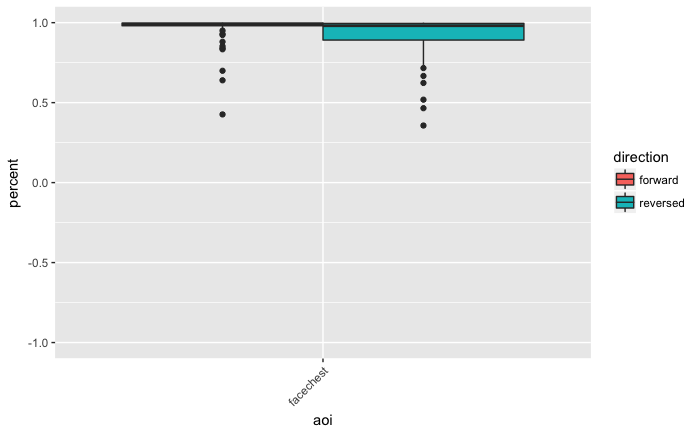

```r
data.indexonly <- data %>%
  filter(aoi == "facechest")
ggplot(data.indexonly,aes(aoi,percent,fill=direction)) +
  geom_boxplot() +
  scale_y_continuous(limits=c(-1,1)) +
  theme(axis.text.x=element_text(angle=45,hjust=1))
```

# Bivariate Correlations

We temporarily drop groups here. We just want to ask: *“What is correlated in terms of subject characteristics and their behavioral measures?”* We’ll do this separately for forward and reversed, and using only important AOIs. We can also ask additional questions like, *which is stronger - signing years or AOA? is lexical recall correlated with looking at any AOI?*

## Behavioral Correlations

First, we’ll look at correlations between participant characteristics, including AoASL, and their performance on the lexical recall task.

`*` p < 0.05 `**` p < 0.01 `***` p < 0.001

```r
# We're going to need to make another data frame with participant-level accuracy information, this time including a reversal effect which we've calculated for each participant.
data.subjectinfo <- data.subjectinfo %>%
  ungroup() %>%
  select(-direction,-acc)
data.acc <- data %>%
  ungroup() %>%
  select(-aoi,-percent) %>%
  distinct() %>%
  group_by(participant,direction) %>%
  dplyr::summarize(mean = mean(acc, na.rm=TRUE)) %>%
  spread(direction,mean) %>%
  mutate(effect = forward - reversed) %>%
  rename(acc.forward = forward,
         acc.reversed = reversed,
         acc.effect = effect) %>%
  left_join(data.subjectinfo, by="participant") %>%
  ungroup() %>%
  distinct() %>%
  select(aoasl,signyrs,selfrate,age,acc.forward,acc.reversed,acc.effect)
#data.acc.results <- Hmisc::rcorr(as.matrix(data.acc))
corstarsl(data.acc) # Use the awesome function!
```

|  | aoasl | signyrs | selfrate | age | acc.forward | acc.reversed |
| --- | --- | --- | --- | --- | --- | --- |
| aoasl |  |  |  |  |  |  |
| signyrs | -0.79*** |  |  |  |  |  |
| selfrate | -0.51*** | 0.71*** |  |  |  |  |
| age | -0.31* | 0.83*** | 0.63*** |  |  |  |
| acc.forward | -0.08 | 0.30* | 0.46*** | 0.36** |  |  |
| acc.reversed | -0.33* | 0.31* | 0.40** | 0.17 | 0.39** |  |
| acc.effect | 0.26 | -0.07 | -0.04 | 0.12 | 0.39** | -0.69*** |

```r
# Gather the AOIs we want
data.allaoi <- data # save current dataset
data <- data %>%
 filter(aoi == "eyes" | aoi == "mouth" | aoi == "chin" | aoi == "face" | aoi == "chest" | aoi == "facechest")
# Need to put AOIs in their own columns
data.spread <- data %>%
  spread(aoi,percent) %>%
  ungroup()
# Fwd and Rev data
data.fw <- data.spread %>%
  filter(direction == "forward") %>%
  select(acc,aoasl,signyrs,selfrate,age,eyes,mouth,chin,face,chest,facechest)
data.rv <- data.spread %>%
  filter(direction == "reversed") %>%
  select(acc,aoasl,signyrs,selfrate,age,eyes,mouth,chin,face,chest,facechest)
# Correlations
# data.fw.corr <- cor(data.fw, use="pairwise.complete.obs")
# data.rv.corr <- cor(data.rv, use="pairwise.complete.obs")
# corrplot.mixed(data.rv.corr, lower ="number", upper = "circle")
```

## Forward Correlations

Here’s the Pearson’s correlation matrix for forward stories.

So. For forward stories it’s a crapshoot.

```r
#Hmisc::rcorr(as.matrix(data.fw))
corstarsl(data.fw)
```

|  | acc | aoasl | signyrs | selfrate | age | eyes | mouth | chin | face | chest |
| --- | --- | --- | --- | --- | --- | --- | --- | --- | --- | --- |
| acc |  |  |  |  |  |  |  |  |  |  |
| aoasl | -0.08 |  |  |  |  |  |  |  |  |  |
| signyrs | 0.30* | -0.79*** |  |  |  |  |  |  |  |  |
| selfrate | 0.46*** | -0.51*** | 0.71*** |  |  |  |  |  |  |  |
| age | 0.36** | -0.31* | 0.83*** | 0.63*** |  |  |  |  |  |  |
| eyes | -0.17 | 0.07 | -0.09 | -0.10 | -0.07 |  |  |  |  |  |
| mouth | 0.18 | -0.06 | 0.22 | 0.12 | 0.25 | -0.65*** |  |  |  |  |
| chin | 0.01 | -0.12 | -0.04 | 0.10 | -0.16 | -0.39** | -0.40** |  |  |  |
| face | 0.12 | -0.24 | 0.38** | 0.31* | 0.37** | -0.11 | 0.46*** | -0.19 |  |  |
| chest | -0.05 | 0.15 | -0.31* | -0.30* | -0.34* | -0.11 | -0.29* | 0.29* | -0.92*** |  |

[output cut: 1 more lines]

## Reversed Correlations

Here’s the Pearson’s correlation matrix for reversed stories.

So.

```r
#Hmisc::rcorr(as.matrix(data.rv))
corstarsl(data.rv)
```

|  | acc | aoasl | signyrs | selfrate | age | eyes | mouth | chin | face | chest |
| --- | --- | --- | --- | --- | --- | --- | --- | --- | --- | --- |
| acc |  |  |  |  |  |  |  |  |  |  |
| aoasl | -0.33* |  |  |  |  |  |  |  |  |  |
| signyrs | 0.31* | -0.78*** |  |  |  |  |  |  |  |  |
| selfrate | 0.40** | -0.51*** | 0.71*** |  |  |  |  |  |  |  |
| age | 0.17 | -0.31* | 0.83*** | 0.63*** |  |  |  |  |  |  |
| eyes | -0.16 | 0.09 | -0.02 | 0.02 | 0.08 |  |  |  |  |  |
| mouth | 0.14 | -0.09 | 0.25 | 0.14 | 0.29* | -0.62*** |  |  |  |  |
| chin | 0.07 | -0.11 | -0.10 | -0.06 | -0.25 | -0.47*** | -0.43** |  |  |  |
| face | 0.27 | -0.25 | 0.38** | 0.28* | 0.36** | -0.18 | 0.59*** | -0.10 |  |  |
| chest | -0.21 | 0.30* | -0.44** | -0.41** | -0.41** | -0.13 | -0.37** | 0.26 | -0.79*** |  |

[output cut: 1 more lines]

## Summary

What have we learned from the bivariate correlations? AoA is correlated with accuracy on the reversed tasks, showing that our manipulation **is** sensitive to effects of AoASL. Specifically, AoASL was correlated with accuracy such that people who acquired ASL later tended to do worse on lexical recall for reversed stories. There was no such relationship found for lexical recall for forward stories.

For no AOI was looking behavior was correlated with accuracy, for either forward or reversed stories. However, AoASL was correlated with looking behavior *only* for reversed stories. Late ASL learners, when confronted with reversed stories, looked more at the chest and less at the face (a more scattered pattern).

Years of signing appeared to have an influence on the amount of time spent looking at the face area, both by itself and in contrast with the chest. People with more signing-years spend more time on the face and less on the chest. *(We can run a quick linear regression on it…it is very significant)*

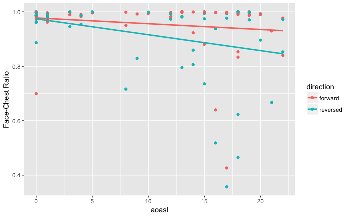

```r
ggplot(filter(data,aoi=="facechest"),aes(x=aoasl,y=percent,color=direction)) +
  geom_point() +
  geom_smooth(method="lm",se=FALSE) +
  ylab("Face-Chest Ratio")
```

# ANOVAs

Now we’re going to do ANOVAs. We’ll do an all-factors ANOVA including Direction, then also do separate Forward and Reversed ANOVAs.

> We do this separately for lexical recall and gaze data. But be prepared to compare the two sets of results side by side, in a summary like say “subject groups differed significantly for lexical recall (stat values) but not gaze data (stat values)” or whatever the result is. At least this can be done in the discussion, if not in the results section.

I like the idea of treating Native Deaf as baseline or the gold standard in comparisons.

## All-ANOVA

Factors: Maingroup & Direction. First ANOVA summary is with Accuracy as outcome, second ANOVA summary is FaceChest Ratio.

```r
data.aov.all <- data %>% filter(aoi=="facechest")
# Lex Recall ANOVA. Outcome: Acc. Factors: MainGroup, Direction
aov.lex.all <- aov(data=data.aov.all, acc ~ maingroup * direction)
aov.lex.all.tidy <- tidy(aov.lex.all)
# Gaze Behavior ANOVA. Outcome: FaceChest. Factors: MainGroup, Direction
aov.gaze.all <- aov(data=data.aov.all, percent ~ maingroup * direction)
aov.gaze.all.tidy <- tidy(aov.gaze.all)
# Prettify
aov.lex.all.tidy <- aov.lex.all.tidy %>%
  select(term,statistic,p.value) %>%
  mutate(statistic = round(statistic,3),
         p.value = round(p.value,3)) %>%
  rename(F.acc = statistic,
         P.acc = p.value)
aov.gaze.all.tidy <- aov.gaze.all.tidy %>%
  select(term,statistic,p.value) %>%
  mutate(statistic = round(statistic,3),
         p.value = round(p.value,3)) %>%
  rename(F.facechest = statistic,
         P.facechest = p.value)
left_join(aov.lex.all.tidy,aov.gaze.all.tidy,by="term") %>%
  print()
```

| term | F.acc | P.acc | F.facechest | P.facechest |
| --- | --- | --- | --- | --- |
| maingroup | 4.672 | 0.002 | 5.700 | 0.000 |
| direction | 75.504 | 0.000 | 3.443 | 0.067 |
| maingroup:direction | 1.306 | 0.273 | 0.804 | 0.525 |
| Residuals | NA | NA | NA | NA |

```r
#TukeyHSD(aov.lex.all,'maingroup',conf.level = 0.95)
#TukeyHSD(aov.gaze.all,'maingroup',conf.level = 0.95)
```

## Forward ANOVA

```r
data.aov.fw <- data %>% filter(aoi=="facechest" & direction=="forward")
# Lex Recall ANOVA. Outcome: Acc. Factors: MainGroup, Direction
aov.lex.fw <- aov(data=data.aov.fw, acc ~ maingroup)
aov.lex.fw.tidy <- tidy(aov.lex.fw)
# Gaze Behavior ANOVA. Outcome: FaceChest. Factors: MainGroup, Direction
aov.gaze.fw <- aov(data=data.aov.fw, percent ~ maingroup)
aov.gaze.fw.tidy <- tidy(aov.gaze.fw)
# Prettify
aov.lex.fw.tidy <- aov.lex.fw.tidy %>%
  select(term,statistic,p.value) %>%
  mutate(statistic = round(statistic,3),
         p.value = round(p.value,3)) %>%
  rename(F.acc = statistic,
         P.acc = p.value)
aov.gaze.fw.tidy <- aov.gaze.fw.tidy %>%
  select(term,statistic,p.value) %>%
  mutate(statistic = round(statistic,3),
         p.value = round(p.value,3)) %>%
  rename(F.facechest = statistic,
         P.facechest = p.value)
left_join(aov.lex.fw.tidy,aov.gaze.fw.tidy,by="term") %>%
  print()
```

| term | F.acc | P.acc | F.facechest | P.facechest |
| --- | --- | --- | --- | --- |
| maingroup | 2.478 | 0.057 | 2.06 | 0.101 |
| Residuals | NA | NA | NA | NA |

```r
#TukeyHSD(aov.lex.fw,'maingroup',conf.level = 0.95)
#TukeyHSD(aov.gaze.fw,'maingroup',conf.level = 0.95)
```

## Reversed ANOVA

```r
data.aov.rv <- data %>% filter(aoi=="facechest" & direction=="reversed")
# Lex Recall ANOVA. Outcome: Acc. Factors: MainGroup, Direction
aov.lex.rv <- aov(data=data.aov.rv, acc ~ maingroup)
aov.lex.rv.tidy <- tidy(aov.lex.rv)
# Gaze Behavior ANOVA. Outcome: FaceChest. Factors: MainGroup, Direction
aov.gaze.rv <- aov(data=data.aov.rv, percent ~ maingroup)
aov.gaze.rv.tidy <- tidy(aov.gaze.rv)
# Prettify
aov.lex.rv.tidy <- aov.lex.rv.tidy %>%
  select(term,statistic,p.value) %>%
  mutate(statistic = round(statistic,3),
         p.value = round(p.value,3)) %>%
  rename(F.acc = statistic,
         P.acc = p.value)
aov.gaze.rv.tidy <- aov.gaze.rv.tidy %>%
  select(term,statistic,p.value) %>%
  mutate(statistic = round(statistic,3),
         p.value = round(p.value,3)) %>%
  rename(F.facechest = statistic,
         P.facechest = p.value)
left_join(aov.lex.rv.tidy,aov.gaze.rv.tidy,by="term") %>%
  print()
```

| term | F.acc | P.acc | F.facechest | P.facechest |
| --- | --- | --- | --- | --- |
| maingroup | 3.384 | 0.017 | 3.872 | 0.009 |
| Residuals | NA | NA | NA | NA |

```r
#TukeyHSD(aov.lex.rv,'maingroup',conf.level = 0.95)
#TukeyHSD(aov.gaze.rv,'maingroup',conf.level = 0.95)
```

## Summary of ANOVAs

What have the ANOVAs told us? Let’s make a table here, and graphs below. We are able to find significant effects of group on both accuracy and face-chest ratio in the all-ANOVA, as well as the reversed ANOVA. However, most of our significant effects of group are driven by HearingNovice doing poorly on accuracy and looking at the hands/chest more. So…the ANOVA story is that, really, Hearing Novices don’t really know ASL well, and that’s why they’re doing poorly. There is no *strong* AoASL story there, it’s more of a L2 language learning thing?.

```r
aov.summary <- tribble(~ANOVA, ~Accuracy, ~FaceChestRatio,
        "All-MainGroup","Sig.","Sig.",
        "All-Direction","Sig.","ns",
        "All-Interactions","ns","ns",
        "Forward-MainGroup","ns","ns",
        "Reversed-MainGroup","Sig.","Sig.")
aov.summary
```

| ANOVA | Accuracy | FaceChestRatio |
| --- | --- | --- |
| All-MainGroup | Sig. | Sig. |
| All-Direction | Sig. | ns |
| All-Interactions | ns | ns |
| Forward-MainGroup | ns | ns |
| Reversed-MainGroup | Sig. | Sig. |

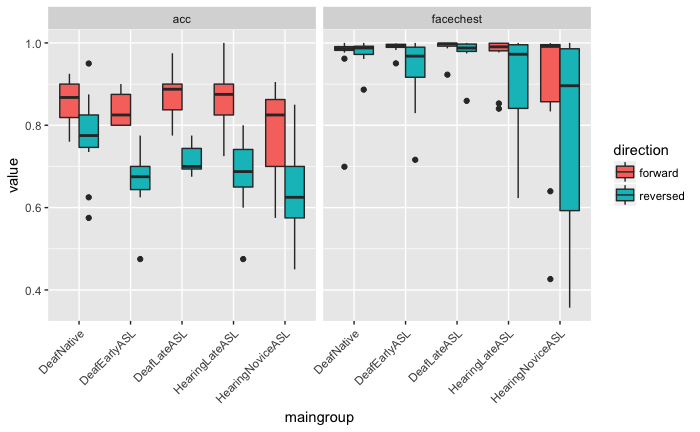

```r
data.aov.chart <- data.aov.all %>%
  select(participant,maingroup,direction,acc,percent) %>%
  rename(facechest = percent) %>%
  gather(metric,value,acc:facechest)
ggplot(data.aov.chart,aes(x=maingroup,y=value,fill=direction)) +
  geom_boxplot() + facet_wrap("metric") +
  theme(axis.text.x=element_text(angle=45,hjust=1))
```

# Recovery

Throwing this in, will move it into a better place for now but it’s great! It supports AoASL effects on the video manipulation. Because look at the medians of each boxplot.

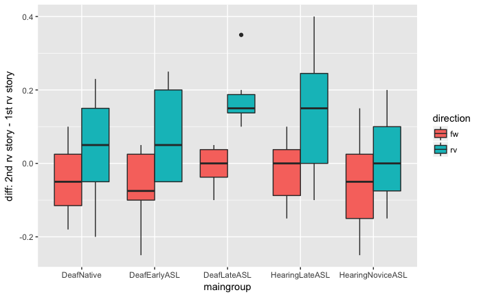

```r
accdiff <- dataoriginal %>%
  select(participant,maingroup,video,acc) %>%
  distinct() %>%
  spread(video,acc) %>%
  mutate(fw = fw3-fw1,
         rv = rv4-rv2) %>%
  select(participant,maingroup,fw,rv) %>%
  gather(direction,diff,fw:rv)
accdiff$maingroup = factor(accdiff$maingroup,levels=c("DeafNative","DeafEarlyASL","DeafLateASL","HearingLateASL","HearingNoviceASL"))
ggplot(accdiff,aes(x=maingroup,y=diff,fill=direction)) + geom_boxplot() + ylab("diff: 2nd rv story - 1st rv story")
```

# Other Notes from Rain

It would be nice to include all lexical data in an ANOVA just to confirm that reversal DOES have an effect on comprehension (it does) and confirm that AoA also has an effect on comprehension, which is to be expected, right? This just backs up what every one else has found – that the later you learn the worse you do.

So maybe think of it as first confirming that we KNOW lexical recall is impacted. That is confirmed with ANOVA. Get that out of the way.

Then, with that confirmed….. then (and only then) we are in a position to ask:* What is the relationship between a) the range of intelligibility scores (accuracy) and gaze…. and b) between AoA and gaze. And you can even load all these factors in together to find the unique variance. * We know who performs well and who performs poorly…. do their gaze behaviors differ?

3. If you do LLM or ANCOVA, do so with AoA, and without subject group or hearing status. I would set aside any stats you did with both Hearing Status and AoA, I don’t think you can do that.

How come lexical recall isn’t a predictor in a model with gaze data? Yes, that is an important goal of the paper.

Here is an example of what I had noted to myself previously, which is not current any more, and I would put correlation values in here:

- Remarkably, percent-looking at mid chest and lower chest, for both forward and reversed (and left side for reversed) are highly negatively correlated with years signing and positively correlated with AoA. That means that greater looking in those areas are associated with older ages of acquisition and fewer years of experience. What is equally interesting is that looking at the eyes was not related to subject characteristics at all (contrast with Emmorey’s finding).
- Also, looking at the mouth for reversed stimuli was significantly correlated with years signing (r = 0.38), this means the longer one signed, the more (in terms of % looking) one looked at the mouth.

Then, maybe we can have a section called “Hearing Status” and in this paragraph say what happens when we compare hearing and deaf, using the same range of AoA, excluding hearing Novice. Or maybe separate regressions for hearing and deaf groups, looking at AoA, AOI’s, and lexical recall, to examine the relationship between the three. I don’t know.

Do you find that NATIVE signers pretty much look at the same place for forward and reversed but that the novice signers show greater dispersion of gaze points for reversed than forward (like more on the chest, by way of lower face looking percent)? Because I always thought that experts are already using their efficient gaze pattern, nothing throws this off…. But novice are easily “thrown off”, gaze-wise. They have very little tolerance of phonetic variation. So they might get really good at understanding their own ASL teacher, and then give them a new variant of a signer, they start to look at the signers’ hands maybe. The same thing happens for the reversed stories, maybe.

```r
# Me trying to run models for eye behavior -> lexical accuracy
datafc <- dataoriginal
model <- lmer(acc ~ percent * signyrs + (1|id) + (1|story), data = filter(datafc,aoi=="mouth" & direction=="forward"))
summary(model)
```

```
Linear mixed model fit by REML t-tests use Satterthwaite approximations to degrees of freedom [lmerMod]
Formula: acc ~ percent * signyrs + (1 | id) + (1 | story)
   Data: filter(datafc, aoi == "mouth" & direction == "forward")

REML criterion at convergence: -172.9

Scaled residuals:
     Min       1Q   Median       3Q      Max
-1.70047 -0.54813  0.02755  0.56490  1.57075

Random effects:
 Groups   Name        Variance Std.Dev.
 id       (Intercept) 0.004572 0.06762
 story    (Intercept) 0.001253 0.03540
 Residual             0.003407 0.05837
Number of obs: 96, groups:  id, 52; story, 4

Fixed effects:
                 Estimate Std. Error        df t value Pr(>|t|)
(Intercept)      0.869297   0.046222 54.510000  18.807   <2e-16 ***
percent         -0.112457   0.062870 89.260000  -1.789   0.0771 .
signyrs         -0.002043   0.002048 89.010000  -0.998   0.3211
percent:signyrs  0.006208   0.002805 82.090000   2.213   0.0297 *
---
Signif. codes:  0 ‘***’ 0.001 ‘**’ 0.01 ‘*’ 0.05 ‘.’ 0.1 ‘ ’ 1

Correlation of Fixed Effects:
            (Intr) percnt sgnyrs
percent     -0.815
signyrs     -0.754  0.707
prcnt:sgnyr  0.704 -0.830 -0.905
```

```r
model <- lmer(percent ~ direction + (1|id), data = filter(datafc,aoi=="mouth"))
summary(model)
```

```
Linear mixed model fit by REML t-tests use Satterthwaite approximations to degrees of freedom [lmerMod]
Formula: percent ~ direction + (1 | id)
   Data: filter(datafc, aoi == "mouth")

REML criterion at convergence: -8.5

Scaled residuals:
     Min       1Q   Median       3Q      Max
-2.60785 -0.47492  0.08233  0.61375  2.32278

Random effects:
 Groups   Name        Variance Std.Dev.
 id       (Intercept) 0.04720  0.2173
 Residual             0.03269  0.1808
Number of obs: 193, groups:  id, 52

Fixed effects:
                   Estimate Std. Error        df t value Pr(>|t|)
(Intercept)         0.63581    0.03532  67.13000  18.004  < 2e-16 ***
directionreversed  -0.09134    0.02622 141.33000  -3.483 0.000661 ***
---
Signif. codes:  0 ‘***’ 0.001 ‘**’ 0.01 ‘*’ 0.05 ‘.’ 0.1 ‘ ’ 1

Correlation of Fixed Effects:
            (Intr)
dirctnrvrsd -0.363
```

```r
# plot(model)
# library(ggfortify)
# autoplot(model2)
# autoplot(model2,which=1:6,data = datafc,colour='direction',label.size=3)
```

# Deaf Hearing Analyses

Let’s try running models with deaf/hearing. First, a scatterplot…

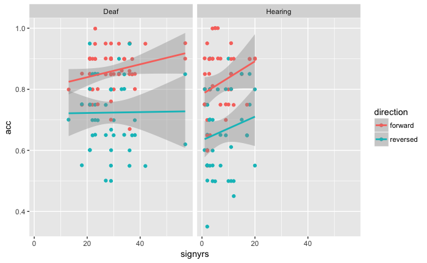

```r
data.acc <- dataoriginal %>% filter(aoi=="facechest")
ggplot(data.acc, aes(x=signyrs,y=acc,color=direction)) + geom_jitter() + geom_smooth(method="lm") + facet_grid(.~hearing)
```

```r
model <- lmer(acc ~ hearing * direction * signyrs + (1|id) + (1|story), data = data.acc)
summary(model)
```

```
Linear mixed model fit by REML t-tests use Satterthwaite approximations to degrees of freedom [lmerMod]
Formula: acc ~ hearing * direction * signyrs + (1 | id) + (1 | story)
   Data: data.acc

REML criterion at convergence: -257.2

Scaled residuals:
     Min       1Q   Median       3Q      Max
-2.06050 -0.61191 -0.01016  0.52982  2.41102

Random effects:
 Groups   Name        Variance Std.Dev.
 id       (Intercept) 0.002876 0.05363
 story    (Intercept) 0.001423 0.03772
 Residual             0.008566 0.09256
Number of obs: 189, groups:  id, 52; story, 4

Fixed effects:
                                           Estimate Std. Error         df t value Pr(>|t|)
(Intercept)                               7.917e-01  6.211e-02  8.122e+01  12.746   <2e-16 ***
hearingHearing                           -8.394e-03  6.578e-02  9.474e+01  -0.128    0.899
directionreversed                        -7.270e-02  6.599e-02  1.322e+02  -1.102    0.273
signyrs                                   2.107e-03  1.955e-03  9.649e+01   1.078    0.284
hearingHearing:directionreversed         -7.468e-02  7.322e-02  1.323e+02  -1.020    0.310
hearingHearing:signyrs                    3.361e-03  3.736e-03  9.651e+01   0.900    0.370
directionreversed:signyrs                -2.025e-03  2.176e-03  1.319e+02  -0.930    0.354
hearingHearing:directionreversed:signyrs  2.881e-04  4.099e-03  1.334e+02   0.070    0.944
---
Signif. codes:  0 ‘***’ 0.001 ‘**’ 0.01 ‘*’ 0.05 ‘.’ 0.1 ‘ ’ 1

Correlation of Fixed Effects:
            (Intr) hrngHr drctnr sgnyrs hrngHrng:d hrngHrng:s drctn:
hearingHrng -0.857
dirctnrvrsd -0.529  0.499
signyrs     -0.916  0.865  0.534
hrngHrng:dr  0.477 -0.555 -0.901 -0.481
hrngHrng:sg  0.479 -0.742 -0.279 -0.524  0.413
drctnrvrsd:  0.509 -0.481 -0.959 -0.557  0.865      0.291
hrngHrng:d: -0.270  0.419  0.508  0.296 -0.746     -0.573     -0.531
```

Eh, no effect here. How about eye gaze…

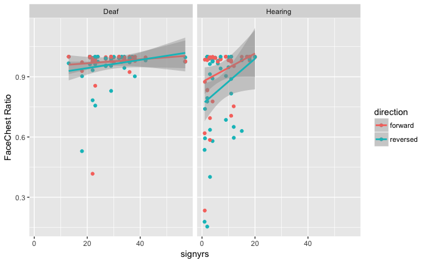

```r
data.fc <- dataoriginal %>% filter(aoi=="facechest")
ggplot(data.fc, aes(x=signyrs,y=percent,color=direction)) + geom_jitter() + geom_smooth(method="lm") + facet_grid(.~hearing) + ylab("FaceChest Ratio")
```

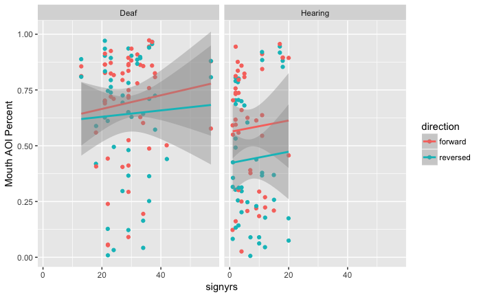

```r
data.mouth <- dataoriginal %>% filter(aoi=="mouth")
ggplot(data.mouth, aes(x=signyrs,y=percent,color=direction)) + geom_jitter() + geom_smooth(method="lm") + facet_grid(.~hearing) + ylab("Mouth AOI Percent")
```

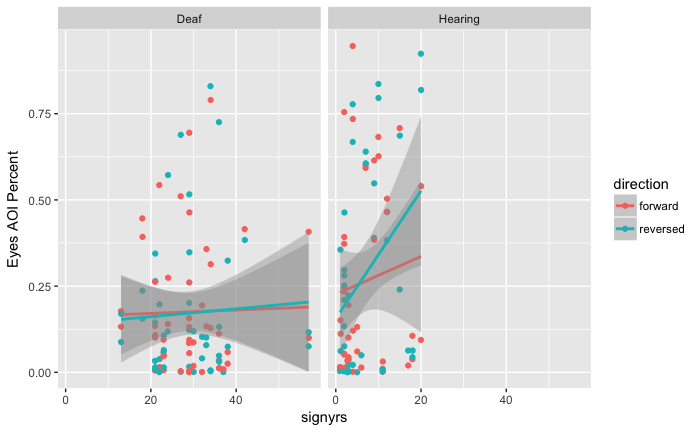

```r
data.eyes <- dataoriginal %>% filter(aoi=="eyes")
ggplot(data.eyes, aes(x=signyrs,y=percent,color=direction)) + geom_jitter() + geom_smooth(method="lm") + facet_grid(.~hearing) + ylab("Eyes AOI Percent")
```

Looks like we’ve got different reversal effects for FaceChest Ratio, Mouth AOI, and Eyes AOI…not terribly strong, though. Let’s run models.

```r
model <- lmer(percent ~ hearing * direction * signyrs + (1|id) + (1|story), data = data.fc)
summary(model)
```

```
Linear mixed model fit by REML t-tests use Satterthwaite approximations to degrees of freedom [lmerMod]
Formula: percent ~ hearing * direction * signyrs + (1 | id) + (1 | story)
   Data: data.fc

REML criterion at convergence: -221.5

Scaled residuals:
    Min      1Q  Median      3Q     Max
-4.9054 -0.1062  0.0588  0.3202  1.7591

Random effects:
 Groups   Name        Variance  Std.Dev.
 id       (Intercept) 0.0099310 0.09965
 story    (Intercept) 0.0002315 0.01522
 Residual             0.0089095 0.09439
Number of obs: 193, groups:  id, 52; story, 4

Fixed effects:
                                           Estimate Std. Error         df t value Pr(>|t|)
(Intercept)                                0.945368   0.081369  68.110000  11.618   <2e-16 ***
hearingHearing                            -0.068859   0.090593  67.210000  -0.760    0.450
directionreversed                         -0.043905   0.064525 135.840000  -0.680    0.497
signyrs                                    0.001081   0.002681  68.030000   0.403    0.688
hearingHearing:directionreversed          -0.069944   0.072232 136.800000  -0.968    0.335
hearingHearing:signyrs                     0.005604   0.005180  70.190000   1.082    0.283
directionreversed:signyrs                  0.001016   0.002142 135.930000   0.474    0.636
hearingHearing:directionreversed:signyrs   0.003715   0.004144 137.530000   0.897    0.372
---
Signif. codes:  0 ‘***’ 0.001 ‘**’ 0.01 ‘*’ 0.05 ‘.’ 0.1 ‘ ’ 1

Correlation of Fixed Effects:
            (Intr) hrngHr drctnr sgnyrs hrngHrng:d hrngHrng:s drctn:
hearingHrng -0.891
dirctnrvrsd -0.395  0.355
signyrs     -0.956  0.859  0.382
hrngHrng:dr  0.353 -0.397 -0.894 -0.342
hrngHrng:sg  0.495 -0.744 -0.198 -0.518  0.300
drctnrvrsd:  0.380 -0.342 -0.957 -0.399  0.857      0.207
hrngHrng:d: -0.197  0.299  0.496  0.208 -0.742     -0.419     -0.519
```

```r
model <- lmer(percent ~ hearing * direction * signyrs + (1|id) + (1|story), data = data.mouth)
summary(model)
```

```
Linear mixed model fit by REML t-tests use Satterthwaite approximations to degrees of freedom [lmerMod]
Formula: percent ~ hearing * direction * signyrs + (1 | id) + (1 | story)
   Data: data.mouth

REML criterion at convergence: 15.2

Scaled residuals:
    Min      1Q  Median      3Q     Max
-2.6678 -0.4859  0.1212  0.5886  2.0450

Random effects:
 Groups   Name        Variance Std.Dev.
 id       (Intercept) 0.045749 0.21389
 story    (Intercept) 0.003448 0.05872
 Residual             0.029281 0.17112
Number of obs: 193, groups:  id, 52; story, 4

Fixed effects:
                                           Estimate Std. Error         df t value Pr(>|t|)
(Intercept)                               6.028e-01  1.683e-01  6.273e+01   3.581 0.000669 ***
hearingHearing                           -2.853e-02  1.854e-01  6.052e+01  -0.154 0.878231
directionreversed                         4.764e-03  1.170e-01  1.338e+02   0.041 0.967583
signyrs                                   2.601e-03  5.482e-03  6.111e+01   0.474 0.636852
hearingHearing:directionreversed         -1.663e-01  1.311e-01  1.342e+02  -1.268 0.206873
hearingHearing:signyrs                    3.866e-05  1.058e-02  6.278e+01   0.004 0.997095
directionreversed:signyrs                -2.038e-03  3.885e-03  1.338e+02  -0.525 0.600756
hearingHearing:directionreversed:signyrs  2.651e-03  7.527e-03  1.347e+02   0.352 0.725261
---
Signif. codes:  0 ‘***’ 0.001 ‘**’ 0.01 ‘*’ 0.05 ‘.’ 0.1 ‘ ’ 1

Correlation of Fixed Effects:
            (Intr) hrngHr drctnr sgnyrs hrngHrng:d hrngHrng:s drctn:
hearingHrng -0.881
dirctnrvrsd -0.346  0.315
signyrs     -0.946  0.859  0.339
hrngHrng:dr  0.309 -0.353 -0.894 -0.303
hrngHrng:sg  0.491 -0.745 -0.176 -0.519  0.267
drctnrvrsd:  0.333 -0.303 -0.957 -0.354  0.856      0.185
hrngHrng:d: -0.173  0.266  0.495  0.184 -0.743     -0.373     -0.519
```

```r
model <- lmer(percent ~ hearing * direction * signyrs + (1|id) + (1|story), data = data.eyes)
summary(model)
```

```
Linear mixed model fit by REML t-tests use Satterthwaite approximations to degrees of freedom [lmerMod]
Formula: percent ~ hearing * direction * signyrs + (1 | id) + (1 | story)
   Data: data.eyes

REML criterion at convergence: -17.7

Scaled residuals:
    Min      1Q  Median      3Q     Max
-2.4992 -0.4637 -0.1208  0.3070  3.7205

Random effects:
 Groups   Name        Variance Std.Dev.
 id       (Intercept) 0.034767 0.18646
 story    (Intercept) 0.001375 0.03709
 Residual             0.023858 0.15446
Number of obs: 176, groups:  id, 52; story, 4

Fixed effects:
                                           Estimate Std. Error         df t value Pr(>|t|)
(Intercept)                               1.544e-01  1.484e-01  6.152e+01   1.041    0.302
hearingHearing                            5.430e-02  1.646e-01  6.001e+01   0.330    0.743
directionreversed                        -3.957e-02  1.083e-01  1.173e+02  -0.365    0.716
signyrs                                   9.223e-04  4.858e-03  6.016e+01   0.190    0.850
hearingHearing:directionreversed         -1.261e-02  1.215e-01  1.177e+02  -0.104    0.917
hearingHearing:signyrs                    4.575e-03  9.369e-03  6.174e+01   0.488    0.627
directionreversed:signyrs                 1.036e-03  3.574e-03  1.170e+02   0.290    0.772
hearingHearing:directionreversed:signyrs  8.837e-03  7.010e-03  1.187e+02   1.261    0.210

Correlation of Fixed Effects:
            (Intr) hrngHr drctnr sgnyrs hrngHrng:d hrngHrng:s drctn:
hearingHrng -0.887
dirctnrvrsd -0.367  0.330
signyrs     -0.952  0.858  0.354
hrngHrng:dr  0.328 -0.371 -0.892 -0.317
hrngHrng:sg  0.494 -0.744 -0.184 -0.519  0.278
drctnrvrsd:  0.352 -0.318 -0.954 -0.370  0.852      0.193
hrngHrng:d: -0.180  0.276  0.486  0.190 -0.734     -0.380     -0.512
```

Let’s ask a very simple question. Are deaf and hearing doing differently on the lexical recall test?

```r
model <- lmer(acc ~ hearing * direction + (1|id) + (1|story), data = data.acc)
summary(model)
```

```
Linear mixed model fit by REML t-tests use Satterthwaite approximations to degrees of freedom [lmerMod]
Formula: acc ~ hearing * direction + (1 | id) + (1 | story)
   Data: data.acc

REML criterion at convergence: -293.6

Scaled residuals:
     Min       1Q   Median       3Q      Max
-2.09522 -0.64935  0.02551  0.57563  2.44869

Random effects:
 Groups   Name        Variance Std.Dev.
 id       (Intercept) 0.003066 0.05537
 story    (Intercept) 0.001417 0.03764
 Residual             0.008504 0.09221
Number of obs: 189, groups:  id, 52; story, 4

Fixed effects:
                                  Estimate Std. Error        df t value Pr(>|t|)
(Intercept)                        0.85293    0.02505   7.25000  34.044 2.86e-09 ***
hearingHearing                    -0.03096    0.02457  95.42000  -1.260    0.211
directionreversed                 -0.13166    0.01861 137.32000  -7.075 6.96e-11 ***
hearingHearing:directionreversed  -0.02712    0.02708 136.14000  -1.002    0.318
---
Signif. codes:  0 ‘***’ 0.001 ‘**’ 0.01 ‘*’ 0.05 ‘.’ 0.1 ‘ ’ 1

Correlation of Fixed Effects:
            (Intr) hrngHr drctnr
hearingHrng -0.444
dirctnrvrsd -0.354  0.359
hrngHrng:dr  0.242 -0.544 -0.682
```

Interestingly they are not. Direction has a big effect here but deaf v. hearing isn’t. How about eye behavior.

```r
model <- lmer(percent ~ hearing * direction + (1|id) + (1|story), data = data.fc)
summary(model)
```

```
Linear mixed model fit by REML t-tests use Satterthwaite approximations to degrees of freedom [lmerMod]
Formula: percent ~ hearing * direction + (1 | id) + (1 | story)
   Data: data.fc

REML criterion at convergence: -253.2

Scaled residuals:
    Min      1Q  Median      3Q     Max
-5.1127 -0.1637  0.0656  0.4088  1.7340

Random effects:
 Groups   Name        Variance  Std.Dev.
 id       (Intercept) 0.0108277 0.10406
 story    (Intercept) 0.0002018 0.01420
 Residual             0.0089273 0.09448
Number of obs: 193, groups:  id, 52; story, 4

Fixed effects:
                                  Estimate Std. Error        df t value Pr(>|t|)
(Intercept)                        0.97680    0.02436  47.87000  40.106   <2e-16 ***
hearingHearing                    -0.05126    0.03493  69.85000  -1.468   0.1467
directionreversed                 -0.01444    0.01874 140.00000  -0.771   0.4422
hearingHearing:directionreversed  -0.06470    0.02752 139.39000  -2.351   0.0201 *
---
Signif. codes:  0 ‘***’ 0.001 ‘**’ 0.01 ‘*’ 0.05 ‘.’ 0.1 ‘ ’ 1

Correlation of Fixed Effects:
            (Intr) hrngHr drctnr
hearingHrng -0.638
dirctnrvrsd -0.365  0.253
hrngHrng:dr  0.248 -0.388 -0.678
```

```r
model <- lmer(percent ~ hearing * direction + (1|id) + (1|story), data = data.mouth)
summary(model)
```

```
Linear mixed model fit by REML t-tests use Satterthwaite approximations to degrees of freedom [lmerMod]
Formula: percent ~ hearing * direction + (1 | id) + (1 | story)
   Data: data.mouth

REML criterion at convergence: -18.3

Scaled residuals:
     Min       1Q   Median       3Q      Max
-2.66774 -0.47980  0.08954  0.60212  2.06463

Random effects:
 Groups   Name        Variance Std.Dev.
 id       (Intercept) 0.043936 0.20961
 story    (Intercept) 0.003408 0.05838
 Residual             0.028918 0.17005
Number of obs: 193, groups:  id, 52; story, 4

Fixed effects:
                                  Estimate Std. Error        df t value Pr(>|t|)
(Intercept)                        0.67822    0.05401  21.13000  12.556 2.89e-11 ***
hearingHearing                    -0.08487    0.06817  64.45000  -1.245   0.2176
directionreversed                 -0.05396    0.03378 137.42000  -1.597   0.1125
hearingHearing:directionreversed  -0.10290    0.04960 136.78000  -2.075   0.0399 *
---
Signif. codes:  0 ‘***’ 0.001 ‘**’ 0.01 ‘*’ 0.05 ‘.’ 0.1 ‘ ’ 1

Correlation of Fixed Effects:
            (Intr) hrngHr drctnr
hearingHrng -0.561
dirctnrvrsd -0.296  0.233
hrngHrng:dr  0.201 -0.359 -0.676
```

```r
model <- lmer(percent ~ hearing * direction + (1|id) + (1|story), data = data.eyes)
summary(model)
```

```
Linear mixed model fit by REML t-tests use Satterthwaite approximations to degrees of freedom [lmerMod]
Formula: percent ~ hearing * direction + (1 | id) + (1 | story)
   Data: data.eyes

REML criterion at convergence: -47.6

Scaled residuals:
    Min      1Q  Median      3Q     Max
-2.7796 -0.4861 -0.1210  0.3115  3.7233

Random effects:
 Groups   Name        Variance Std.Dev.
 id       (Intercept) 0.035204 0.18763
 story    (Intercept) 0.001676 0.04094
 Residual             0.023844 0.15442
Number of obs: 176, groups:  id, 52; story, 4

Fixed effects:
                                   Estimate Std. Error         df t value Pr(>|t|)
(Intercept)                        0.181117   0.046191  30.790000   3.921 0.000459 ***
hearingHearing                     0.067607   0.062051  64.540000   1.090 0.279965
directionreversed                 -0.008796   0.032577 123.350000  -0.270 0.787598
hearingHearing:directionreversed   0.026508   0.047558 121.730000   0.557 0.578289
---
Signif. codes:  0 ‘***’ 0.001 ‘**’ 0.01 ‘*’ 0.05 ‘.’ 0.1 ‘ ’ 1

Correlation of Fixed Effects:
            (Intr) hrngHr drctnr
hearingHrng -0.598
dirctnrvrsd -0.322  0.238
hrngHrng:dr  0.220 -0.362 -0.681
```

Okay, so we get interactions for FaceChest Ratio and for Mouth…hearing and reversed do “worse”. That at least. Of course, I’m worried about the Novice screwing up those results…let’s check. Okay I checked all the models again with HearingNovice taken out, and yep, the effects disappeared.

What if we compared DeafLate and HearingLate, using signyrs as a covariate?

```r
data.acc.late <- data.acc %>% filter(maingroup=="HearingLateASL" | maingroup=="DeafLateASL")
model <- lmer(acc ~ hearing * direction * signyrs + (1|id) + (1|story), data = data.acc.late)
summary(model)
```

```
Linear mixed model fit by REML t-tests use Satterthwaite approximations to degrees of freedom [lmerMod]
Formula: acc ~ hearing * direction * signyrs + (1 | id) + (1 | story)
   Data: data.acc.late

REML criterion at convergence: -73.9

Scaled residuals:
     Min       1Q   Median       3Q      Max
-2.00529 -0.56776  0.02437  0.49060  2.42451

Random effects:
 Groups   Name        Variance Std.Dev.
 id       (Intercept) 0.002091 0.04572
 story    (Intercept) 0.002223 0.04715
 Residual             0.008697 0.09326
Number of obs: 73, groups:  id, 20; story, 4

Fixed effects:
                                          Estimate Std. Error        df t value Pr(>|t|)
(Intercept)                               0.709832   0.162404 47.210000   4.371 6.76e-05 ***
hearingHearing                            0.180327   0.173830 44.590000   1.037    0.305
directionreversed                         0.055002   0.199187 47.040000   0.276    0.784
signyrs                                   0.006700   0.006706 45.410000   0.999    0.323
hearingHearing:directionreversed         -0.300184   0.216218 47.560000  -1.388    0.172
hearingHearing:signyrs                   -0.009230   0.008529 41.870000  -1.082    0.285
directionreversed:signyrs                -0.008825   0.008351 47.500000  -1.057    0.296
hearingHearing:directionreversed:signyrs  0.014511   0.010551 48.180000   1.375    0.175
---
Signif. codes:  0 ‘***’ 0.001 ‘**’ 0.01 ‘*’ 0.05 ‘.’ 0.1 ‘ ’ 1

Correlation of Fixed Effects:
            (Intr) hrngHr drctnr sgnyrs hrngHrng:d hrngHrng:s drctn:
hearingHrng -0.920
dirctnrvrsd -0.610  0.579
signyrs     -0.972  0.914  0.608
hrngHrng:dr  0.567 -0.615 -0.933 -0.568
hrngHrng:sg  0.770 -0.932 -0.491 -0.794  0.576
drctnrvrsd:  0.599 -0.571 -0.983 -0.618  0.920      0.502
hrngHrng:d: -0.481  0.576  0.794  0.499 -0.939     -0.616     -0.811
```

```r
data.fc.late <- data.fc %>% filter(maingroup=="HearingLateASL" | maingroup=="DeafLateASL")
model <- lmer(percent ~ hearing * direction * signyrs + (1|id) + (1|story), data = data.fc.late)
summary(model)
```

```
Linear mixed model fit by REML t-tests use Satterthwaite approximations to degrees of freedom [lmerMod]
Formula: percent ~ hearing * direction * signyrs + (1 | id) + (1 | story)
   Data: data.fc.late

REML criterion at convergence: -103.5

Scaled residuals:
    Min      1Q  Median      3Q     Max
-3.3094 -0.1773  0.0360  0.4459  1.7308

Random effects:
 Groups   Name        Variance  Std.Dev.
 id       (Intercept) 0.0039593 0.06292
 story    (Intercept) 0.0002182 0.01477
 Residual             0.0051858 0.07201
Number of obs: 75, groups:  id, 20; story, 4

Fixed effects:
                                           Estimate Std. Error         df t value Pr(>|t|)
(Intercept)                               9.799e-01  1.390e-01  2.473e+01   7.048 2.32e-07 ***
hearingHearing                           -1.965e-02  1.533e-01  2.479e+01  -0.128    0.899
directionreversed                        -4.865e-03  1.260e-01  5.140e+01  -0.039    0.969
signyrs                                   4.074e-04  5.879e-03  2.514e+01   0.069    0.945
hearingHearing:directionreversed         -6.917e-02  1.408e-01  5.126e+01  -0.491    0.625
hearingHearing:signyrs                    2.119e-05  7.836e-03  2.561e+01   0.003    0.998
directionreversed:signyrs                -5.631e-04  5.396e-03  5.107e+01  -0.104    0.917
hearingHearing:directionreversed:signyrs  2.279e-03  7.272e-03  5.119e+01   0.313    0.755
---
Signif. codes:  0 ‘***’ 0.001 ‘**’ 0.01 ‘*’ 0.05 ‘.’ 0.1 ‘ ’ 1

Correlation of Fixed Effects:
            (Intr) hrngHr drctnr sgnyrs hrngHrng:d hrngHrng:s drctn:
hearingHrng -0.907
dirctnrvrsd -0.453  0.416
signyrs     -0.976  0.888  0.449
hrngHrng:dr  0.410 -0.455 -0.905 -0.407
hrngHrng:sg  0.736 -0.925 -0.343 -0.754  0.427
drctnrvrsd:  0.443 -0.408 -0.978 -0.459  0.887      0.352
hrngHrng:d: -0.334  0.422  0.738  0.347 -0.928     -0.464     -0.757
```

```r
data.mouth.late <- data.fc %>% filter(maingroup=="HearingLateASL" | maingroup=="DeafLateASL")
model <- lmer(percent ~ hearing * direction * signyrs + (1|id) + (1|story), data = data.mouth.late)
summary(model)
```

```
Linear mixed model fit by REML t-tests use Satterthwaite approximations to degrees of freedom [lmerMod]
Formula: percent ~ hearing * direction * signyrs + (1 | id) + (1 | story)
   Data: data.mouth.late

REML criterion at convergence: -103.5

Scaled residuals:
    Min      1Q  Median      3Q     Max
-3.3094 -0.1773  0.0360  0.4459  1.7308

Random effects:
 Groups   Name        Variance  Std.Dev.
 id       (Intercept) 0.0039593 0.06292
 story    (Intercept) 0.0002182 0.01477
 Residual             0.0051858 0.07201
Number of obs: 75, groups:  id, 20; story, 4

Fixed effects:
                                           Estimate Std. Error         df t value Pr(>|t|)
(Intercept)                               9.799e-01  1.390e-01  2.473e+01   7.048 2.32e-07 ***
hearingHearing                           -1.965e-02  1.533e-01  2.479e+01  -0.128    0.899
directionreversed                        -4.865e-03  1.260e-01  5.140e+01  -0.039    0.969
signyrs                                   4.074e-04  5.879e-03  2.514e+01   0.069    0.945
hearingHearing:directionreversed         -6.917e-02  1.408e-01  5.126e+01  -0.491    0.625
hearingHearing:signyrs                    2.119e-05  7.836e-03  2.561e+01   0.003    0.998
directionreversed:signyrs                -5.631e-04  5.396e-03  5.107e+01  -0.104    0.917
hearingHearing:directionreversed:signyrs  2.279e-03  7.272e-03  5.119e+01   0.313    0.755
---
Signif. codes:  0 ‘***’ 0.001 ‘**’ 0.01 ‘*’ 0.05 ‘.’ 0.1 ‘ ’ 1

Correlation of Fixed Effects:
            (Intr) hrngHr drctnr sgnyrs hrngHrng:d hrngHrng:s drctn:
hearingHrng -0.907
dirctnrvrsd -0.453  0.416
signyrs     -0.976  0.888  0.449
hrngHrng:dr  0.410 -0.455 -0.905 -0.407
hrngHrng:sg  0.736 -0.925 -0.343 -0.754  0.427
drctnrvrsd:  0.443 -0.408 -0.978 -0.459  0.887      0.352
hrngHrng:d: -0.334  0.422  0.738  0.347 -0.928     -0.464     -0.757
```

```r
data.eyes.late <- data.fc %>% filter(maingroup=="HearingLateASL" | maingroup=="DeafLateASL")
model <- lmer(percent ~ hearing * direction * signyrs + (1|id) + (1|story), data = data.eyes.late)
summary(model)
```

```
Linear mixed model fit by REML t-tests use Satterthwaite approximations to degrees of freedom [lmerMod]
Formula: percent ~ hearing * direction * signyrs + (1 | id) + (1 | story)
   Data: data.eyes.late

REML criterion at convergence: -103.5

Scaled residuals:
    Min      1Q  Median      3Q     Max
-3.3094 -0.1773  0.0360  0.4459  1.7308

Random effects:
 Groups   Name        Variance  Std.Dev.
 id       (Intercept) 0.0039593 0.06292
 story    (Intercept) 0.0002182 0.01477
 Residual             0.0051858 0.07201
Number of obs: 75, groups:  id, 20; story, 4

Fixed effects:
                                           Estimate Std. Error         df t value Pr(>|t|)
(Intercept)                               9.799e-01  1.390e-01  2.473e+01   7.048 2.32e-07 ***
hearingHearing                           -1.965e-02  1.533e-01  2.479e+01  -0.128    0.899
directionreversed                        -4.865e-03  1.260e-01  5.140e+01  -0.039    0.969
signyrs                                   4.074e-04  5.879e-03  2.514e+01   0.069    0.945
hearingHearing:directionreversed         -6.917e-02  1.408e-01  5.126e+01  -0.491    0.625
hearingHearing:signyrs                    2.119e-05  7.836e-03  2.561e+01   0.003    0.998
directionreversed:signyrs                -5.631e-04  5.396e-03  5.107e+01  -0.104    0.917
hearingHearing:directionreversed:signyrs  2.279e-03  7.272e-03  5.119e+01   0.313    0.755
---
Signif. codes:  0 ‘***’ 0.001 ‘**’ 0.01 ‘*’ 0.05 ‘.’ 0.1 ‘ ’ 1

Correlation of Fixed Effects:
            (Intr) hrngHr drctnr sgnyrs hrngHrng:d hrngHrng:s drctn:
hearingHrng -0.907
dirctnrvrsd -0.453  0.416
signyrs     -0.976  0.888  0.449
hrngHrng:dr  0.410 -0.455 -0.905 -0.407
hrngHrng:sg  0.736 -0.925 -0.343 -0.754  0.427
drctnrvrsd:  0.443 -0.408 -0.978 -0.459  0.887      0.352
hrngHrng:d: -0.334  0.422  0.738  0.347 -0.928     -0.464     -0.757
```

Ehhhh. Wha tabout using gaze behavior to predict accuracy, would that differ based on deafness?

```r
model <- lmer(acc ~ percent * aoasl * direction * hearing + (1|id) + (1|story), data = data.eyes)
summary(model)
```

```
Linear mixed model fit by REML t-tests use Satterthwaite approximations to degrees of freedom [lmerMod]
Formula: acc ~ percent * aoasl * direction * hearing + (1 | id) + (1 |      story)
   Data: data.eyes

REML criterion at convergence: -204.4

Scaled residuals:
     Min       1Q   Median       3Q      Max
-2.44320 -0.53124  0.01888  0.52296  2.15330

Random effects:
 Groups   Name        Variance Std.Dev.
 id       (Intercept) 0.003829 0.06188
 story    (Intercept) 0.001612 0.04015
 Residual             0.007943 0.08912
Number of obs: 172, groups:  id, 52; story, 4

Fixed effects:
                                                 Estimate Std. Error         df t value Pr(>|t|)
(Intercept)                                      0.852542   0.035269  20.660000  24.173  < 2e-16 ***
percent                                         -0.015586   0.102953 144.450000  -0.151 0.879880
aoasl                                            0.001309   0.003449 116.300000   0.379 0.705038
directionreversed                               -0.124240   0.035335 133.900000  -3.516 0.000598 ***
hearingHearing                                  -0.031431   0.202203 114.810000  -0.155 0.876747
percent:aoasl                                   -0.003674   0.012099 143.980000  -0.304 0.761796
percent:directionreversed                        0.055902   0.151347 142.730000   0.369 0.712403
aoasl:directionreversed                         -0.001915   0.003913 124.110000  -0.489 0.625498
percent:hearingHearing                           0.082488   0.453610 134.030000   0.182 0.855977
aoasl:hearingHearing                            -0.001501   0.011626 116.940000  -0.129 0.897526
directionreversed:hearingHearing                -0.432235   0.240891 125.620000  -1.794 0.075167 .
percent:aoasl:directionreversed                 -0.007179   0.018674 133.390000  -0.384 0.701265
percent:aoasl:hearingHearing                    -0.001482   0.028120 144.910000  -0.053 0.958051
percent:directionreversed:hearingHearing         1.000858   0.520702 127.550000   1.922 0.056819 .
aoasl:directionreversed:hearingHearing           0.027178   0.014003 126.350000   1.941 0.054497 .
percent:aoasl:directionreversed:hearingHearing  -0.061338   0.034818 129.920000  -1.762 0.080477 .
---
Signif. codes:  0 ‘***’ 0.001 ‘**’ 0.01 ‘*’ 0.05 ‘.’ 0.1 ‘ ’ 1
```

```
Correlation matrix not shown by default, as p = 16 > 12.
Use print(x, correlation=TRUE)  or
     vcov(x)     if you need it
```